# LuthraSauravPS4A

Saurav Luthra

2025-03-22

# SAURAV LUTHRA, MTH643 PROBLEM SET 4A

## =========== OVERVIEW ===========

**HP :** Helmerich & Payne, Inc. (NYSE)

**PDS :** Precision Drilling Corporation (NYSE)

## =========== SETUP ===========

```r
# ==============================================================================
# GET DATA AND SETUP FOR HP

getSymbols("HP", src = "yahoo", from = as.Date("2020-02-01", to = as.Date("2025-02-01")))
```

```
## [1] "HP"
```

```r
HP_prices <- (HP$HP.Adjusted)

HP_log_returns <- as.vector(diff(log(HP_prices))[-1])

# ==============================================================================
# GET DATA AND SETUP FOR PDS

getSymbols("PDS", src = "yahoo", from = as.Date("2020-02-01", to = as.Date("2025-02-01")))
```

```
## [1] "PDS"
```

```r
PDS_prices <- (PDS$PDS.Adjusted)

PDS_log_returns <- as.vector(diff(log(PDS_prices))[-1])
```

## =========== QUESTION 0 ===========

#### [**HP Log Returns vs PDS Log Returns**]

From Problem Set 3, Question 4:

The scatter plot below shows that the log returns of HP and PDS are quite correlated, and hence, seem to be generally following the blue y=x line. This means that on any given day, the log return of HP and PDS are likely to be 1:1 with some level of variance. There are a small number of drastic outliers of huge negative and positive returns, however in those scenarios, HP and PDS generally still move equivalently. This has a lot to do with the fact that both these companies are in the same industry, same country, and have similar fundamental and financial characteristics.

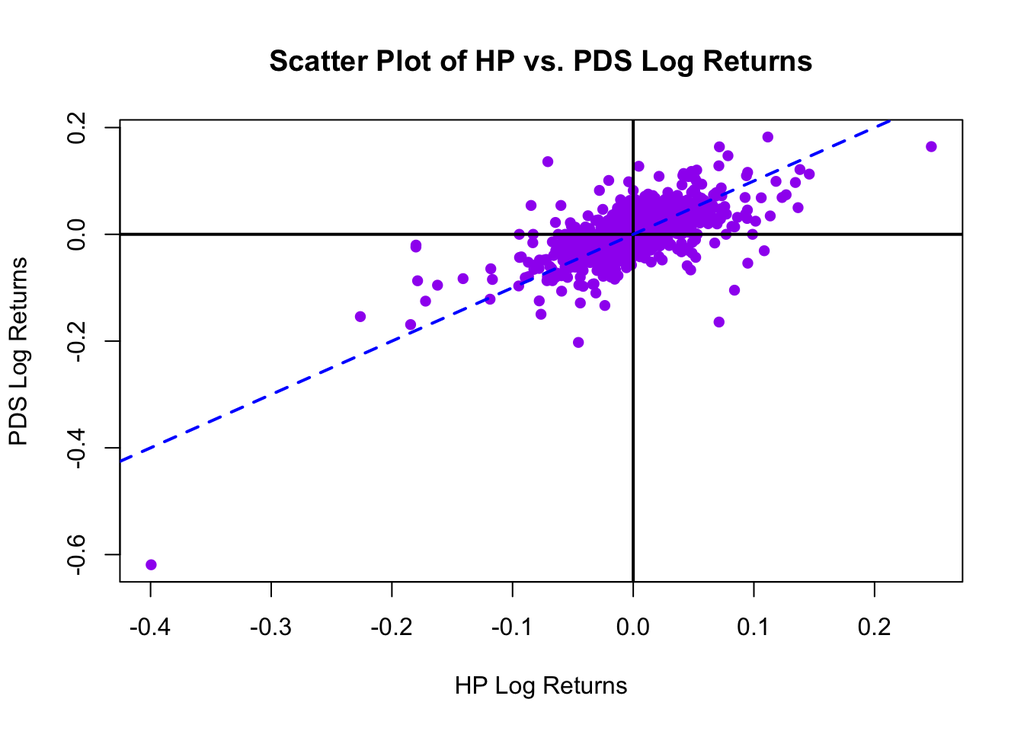

```r
# ==============================================================================
# SCATTER PLOT HP LOG-RETURNS VS PDS LOG RETURNS

plot(HP_log_returns, PDS_log_returns,
     main = "Scatter Plot of HP vs. PDS Log Returns",
     xlab = "HP Log Returns",
     ylab = "PDS Log Returns",
     col = "purple",
     pch = 16)

# add vertical and horizontal lines at 0
abline(v = 0, col = "black", lty = 1, lwd = 2)
abline(h = 0, col = "black", lty = 1, lwd = 2)

# blue dashed line at y = x
abline(0, 1, col = "blue", lwd = 2, lty = 2)
```

## =========== QUESTION 1 ===========

#### [**Bivariate T-Distribution**]

For the pair (HP_log_returns, PDS_log_returns) we use the maximum likelihood method to fit a bivariate T-distribution to model the underlying pairs of log returns.

1. We search for the MLE of ν (degrees of freedom) between 2.5 - 4.49 in increments of 0.01 (200 values), generating a profile log-likelihood graph with a 95% confidence interval.
2. Using that MLE of ν, the best fit for µ (mean vector) and Λ (correlation matrix) were computed.

The MLE was:

**ν** = 3.33

**µ** = [-0.000334 0.000240]

**Λ** = [[1 0.668743], [0.668743 1]]

**95% Confidence Interval** = (2.875, 3.875)

This seems to be a decent fit for the bivariate data, although, the confidence interval for the MLE of **ν** seems a little wide. At a width of 1.00, it seems like the true value of **ν** could vary a lot in relative terms. There was a similar size on the confidence interval on page 168 of the RM textbook, but the estimated **ν** was higher. The lower value of the **ν** MLE also further suggests that there is a high degree of outliers in the data, which we need fat tails to appropriately account for. This is in line with all previous analysis of the log-returns of HP and PDS, which also had fat tails, although those analyses only dealt with univariate T-distributions. Additionally, the mean vectors tells us that HP has a slightly average negative log-return whereas PDS has a slightly positive one. Their correlation is also pretty high in this case, however for small values of **ν** the true correlation is weaker than what Λ suggests.

```r
# ==============================================================================
# SETUP

data   <- cbind(HP_log_returns, PDS_log_returns)
df     <- seq(2.5, 4.49, 0.01)
n      <- length(df)
loglik <- rep(0, n)

# number of parameters = df + means + unique cov terms (d(d+1)/2)
k <- 1 + 2 + 3

shift = 10780

# ==============================================================================
# GET LOG-LIKELIHOOD OF DIFFERENT VALUES OF NU (DOF)

for(i in 1:n){
  fit = cov.trob(data, nu = df[i])
  loglik[i] = sum(log(dmt(data, mean = fit$center, S = fit$cov, df = df[i])))
}

# ==============================================================================
# GET AIC_T

aic_t = -2*max(loglik) + 2*k + shift
cat("\nAIC_T: ", aic_t)
```

```
##
## AIC_T:  2.260469
```

```r
# ==============================================================================
# COMPUTE 95% CONFIDENCE INTERVAL

z1 = (2*loglik > 2 *max(loglik) - qchisq(0.95, 1))
cat("\nZ1 False Indices:\n ", which(z1 == FALSE))
```

```
##
## Z1 False Indices:
##   1 2 3 4 5 6 7 8 9 10 11 12 13 14 15 16 17 18 19 20 21 22 23 24 25 26 27 28 29 30 31 32 33 34 35 36 37 38 139 140 141 142 143 144 145 146 147 148 149 150 151 152 153 154 155 156 157 158 159 160 161 162 163 164 165 166 167 168 169 170 171 172 173 174 175 176 177 178 179 180 181 182 183 184 185 18…
```

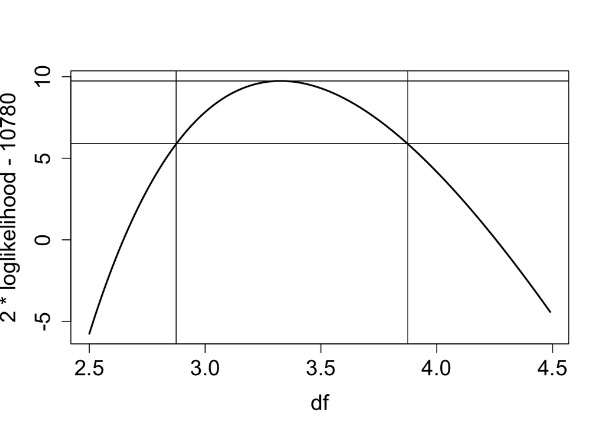

```r
# ==============================================================================
# PLOT PROFILE LOG-LIKELIHOOD VS. DOF

plot(df, 2 * loglik - shift, type = "l", cex.axis = 1.5, cex.lab = 1.5, ylab = paste0("2 * loglikelihood - ", shift), lwd = 2)

abline(h = 2 * max(loglik) - qchisq(0.95, 1) - shift)
abline(h = 2 * max(loglik) - shift)

abline(v = (df[38] + df[39]) / 2)
abline(v = (df[138] + df[139]) / 2)
```

```r
cat("\nLower Bound: ",(df[38] + df[39]) / 2)
```

```
##
## Lower Bound:  2.875
```

```r
cat("\nHigher Bound: ", (df[138] + df[139]) / 2)
```

```
##
## Higher Bound:  3.875
```

```r
# ==============================================================================
# OUTPUT BEST VALUE FOR DOF AND BIVARIATE T-DISTRIBUTION

best_nu <- df[which.max(loglik)]
bestfit <- cov.trob(data,nu=best_nu,cor=TRUE)

cat("\nBest Value for DoF: ", best_nu)
```

```
##
## Best Value for DoF:  3.33
```

```r
cat("\nBest Fit Mean Vector: ", bestfit$center)
```

```
##
## Best Fit Mean Vector:  -0.0003344055 0.0002401627
```

```r
cat("\nBest Fit Correlation Matrix: ", bestfit$cor)
```

```
##
## Best Fit Correlation Matrix:  1 0.6687426 0.6687426 1
```

## =========== QUESTION 2 ===========

#### [**Univariate T-Distributions**]

Using the ‘fitdistr’ command from the ‘MASS’ library to fit 2 univariate t-distributions to each log return series. The following are the mean, scale parameter, standard deviation, and degrees of freedom of each fitted T-distribution. The DoF values are quite close to that of the bivariate distribution (3.33). Overally, both stocks have relatively similar univariate T-distributions across all parameters.

**HP Log Returns T-Distribution:**

Mean: -0.0001147878

Scale Parameter: 0.02486408

Degrees of Freedom: 3.371296

Standard Deviation: 0.03898569

**PDS Log Returns T-Distribution:**

Mean: 0.0004078942

Scale Parameter: 0.02755748

Degrees of Freedom: 3.636176

Standard Deviation: 0.04108155

The standard deviation was computed using the scale parameter and degrees of freedom using the following:

$$\sigma = s \times \sqrt{\frac{\nu}{\nu -
2}}$$

```r
est_HP = as.numeric(fitdistr(HP_log_returns, "t")$estimate)
std_HP <- est_HP[2] * sqrt(est_HP[3] / (est_HP[3] - 2))

est_PDS = as.numeric(fitdistr(PDS_log_returns, "t")$estimate)
std_PDS <- est_PDS[2] * sqrt(est_PDS[3] / (est_PDS[3] - 2))

# print results
cat("HP Log Returns:\n")
```

```
## HP Log Returns:
```

```r
cat("Mean:", est_HP[1], "\n")
```

```
## Mean: -0.0001147873
```

```r
cat("Scale Parameter:", est_HP[2], "\n")
```

```
## Scale Parameter: 0.02486406
```

```r
cat("Degrees of Freedom:", est_HP[3], "\n")
```

```
## Degrees of Freedom: 3.371294
```

```r
cat("Standard Deviation:", std_HP, "\n\n")
```

```
## Standard Deviation: 0.03898568
```

```r
cat("PDS Log Returns:\n")
```

```
## PDS Log Returns:
```

```r
cat("Mean:", est_PDS[1], "\n")
```

```
## Mean: 0.0004078942
```

```r
cat("Scale Parameter:", est_PDS[2], "\n")
```

```
## Scale Parameter: 0.02755748
```

```r
cat("Degrees of Freedom:", est_PDS[3], "\n")
```

```
## Degrees of Freedom: 3.636176
```

```r
cat("Standard Deviation:", std_PDS, "\n")
```

```
## Standard Deviation: 0.04108155
```

## =========== QUESTION 3 ===========

#### [**Sample Kendall’s Tau Rank Correlation and Sample Pearson Correlation**]

**Pearson correlation: 0.6747**

**Kendall’s Tau: 0.4764**

The correlation between the log-returns of HP and PDS, suggests a strong positive relationship. However, the difference between these values highlights key nuances in how each measure computes correlation. Pearson correlation captures linear dependence by comparing the raw log-return values, which makes it more sensitive to extreme values and outliers, like we have in this dataset. In contrast, Kendall’s Tau assesses rank correlation, only measuring how consistently one stock’s returns move relative to the other in an ordinal way, regardless of magnitude. Because Kendall’s Tau only considers **relative ordering** of returns rather than their actual numerical values, it tends to be **lower than Pearson** when in cases such as the log-return dataset where we have deviations from a strict monotonic relationship.

While HP and PDS definitely tend to move in the same direction, the strength of their movements is not perfectly consistent. This could imply that while a positive return in HP generally corresponds with a positive return in PDS, there are instances where one stock’s gain is disproportionately larger or smaller than the other’s. This is clearly visible in QUESTION 0, in the scatter plot of HP log-returns vs PDS log-returns.

Although the stocks are in the same country and industry,the gap between these two correlation values further show periods of nonlinearity between both log-returns response to market conditions. For example, since HP and PDS share common macroeconomic risk factors, they exhibit high linear correlation during broader market movements (the majority of returns) but weaker rank correlation when idiosyncratic or industry-specific factors dominate.

```r
# Pearson correlation
paste0("Pearson Correlation: ", cor(HP_log_returns, PDS_log_returns, method = "pearson"))
```

```
## [1] "Pearson Correlation: 0.6747495165885"
```

```r
# cor.test(HP_log_returns, PDS_log_returns, method = "pearson")

# Kendall's Tau correlation
paste0("Kendall's Tau Correlation:", cor(HP_log_returns, PDS_log_returns, method = "kendall"))
```

```
## [1] "Kendall's Tau Correlation:0.476403898853862"
```

```r
# cor.test(HP_log_returns, PDS_log_returns, method = "kendall")
```